# MIKC_tree_workflow-basalclades-v4

Now let's first get the sequence names in a file:

```bash
grep '>' data/alignments_trimmed/MIKC_orthogroup_selection-basal-v3_guide-v4_aligned-mafft-einsi_trim-gt1-seqrmmanual.fasta | tr -d '>' | tee ./data/MIKC_orthogroup_selection-basal-v4_guide-v4.txt
```

```
tr|Q5KU24|Q5KU24_COLSC_MADS-box_transcription_factor_CsMADS1_OS=Coleochaete_scutata_OX=3125_GN=csmads1_PE=2_SV=1
tr|Q5KTX4|Q5KTX4_9VIRI_MADS-box_protein_CpMADS1_(Fragment)_OS=Closterium_peracerosum-strigosum-littorale_complex_OX=34146_GN=CpMADS1_PE=2_SV=1
cgMADS1_BAD88436
CRM1_CAA69276
CRM2_CAA69277
CRM3_CAA69407
CRM4_CAA69408
CRM5_CAA69409
CRM6_CAA69410
CRM7_CAA69411
OPM1_CAA69412
CMADS1_AAC24492
CMADS2_AAC24493
CMADS3_AAC24319
CMADS4_AAC24320
CMADS6_AAC24325
SmMADS6
SmMADS4
SmMADS3
SmMADS2
SmMADS10
SmMADS1
PPM1_Pp012G078200
PPM2_Pp003G125000
PpMADS1_Pp004G002000
PpMADS_S
PPMC5_Pp017G019900
PPMC6_Pp014G056100
PpMADS2_Pp012G080000
PpMADS3_Pp003G124300
PPM3_Pp014G086000
PPM4_Pp001G158500
PPM6_Pp008G025800
PPM7_Pp017G043700
PPMA8_Pp008G025900
PPMA9_Pp003G124400
PPMA11_Pp001G158400
PPMA12_Pp004G013900
Pp014G086100
PI
```

[output cut: 195 more lines]

```
PIVW-2003992-Ceratopteris_thalictroides
PIVW-2009413-Ceratopteris_thalictroides
CBAE-2012867-Huperzia_myrisinites
ZFRE-2001131-Phaeoceros_carolinianus-sporophyte_1575
PIVW-2000173-Ceratopteris_thalictroides
JVSZ-2014659-Equisetum_hymale
UPMJ-2017788-Pseudolycopodiella_caroliniana
PIVW-2004302-Ceratopteris_thalictroides
PIVW-2009414-Ceratopteris_thalictroides
PIVW-2007999-Ceratopteris_thalictroides
NRWZ-2014421-Metzgeria_crassipilis
PIVW-2001493-Ceratopteris_thalictroides
RDOO-2015055-Racomitrium_varium
CVEG-2123825-Azolla_cf._caroliniana
CVEG-2010487-Azolla_cf._caroliniana
```

```bash
wc -l ./data/MIKC_orthogroup_selection-basal-v4_guide-v4.txt
```

```
250 ./data/MIKC_orthogroup_selection-basal-v4_guide-v4.txt
```

And now extract these sequences from the original unaligned file (once that is linearised)

```bash
inseq='MIKC_orthogroup_selection-basal-v3_guide-v4'
grep '>' -c data/$inseq.fasta
head data/$inseq.fasta
```

```
425
>tr|Q5KU24|Q5KU24_COLSC MADS-box transcription factor CsMADS1 OS=Coleochaete scutata OX=3125 GN=csmads1 PE=2 SV=1
MGRGKIEIRRIENATSRQVTFSKRRNGLLKKAYELSVLCDVDIAVIVFSPTGKLFQYASS
SMKEILERYEQVPPEQKEKGSQRLDNMDYLNREVAKLRNEVEHKYHEARQLEGEDLDRLG
VYELEQLEQKLSNSMRRIRGRKDELMKAELEGLRKQVADMETALVGAASFDGRPLSGSSN
YLLQSIPGIRTMPPSSLGGMNPASTSLQLGSDRLFGNRGVELHDRSASDESPVMTNRMSV
DFAQAPREMSGVDLSGSPVPPWKSQAAAAAQQEWKNQASSPTDWKVTNTEHLDSWPKAPA
PTPEWKSTSVQPEWKNQSSPSSEWKPLDWMYHGPQD
>tr|Q5KTX4|Q5KTX4_9VIRI MADS-box protein CpMADS1 (Fragment) OS=Closterium peracerosum-strigosum-littorale complex OX=34146 GN=CpMADS1 PE=2 SV=1
MGRGKIEIRKIDNATTRQVTFSKRRNGLLKKAYELAVLCDVEIGVIIFSATGKLFQYAST
NMDSIVERYRRLALETGKDPRPPWQQQNPPQSTGLGAQHGQHNKHGKEKPGQLQARTQQQ
```

```bash
cat data/$inseq.fasta \
  | awk '/^>/ {printf("%s%s\n",(N>0?"\n":""),$0);N++;next;} {printf("%s",$0);} END {printf("\n");}' \
  > data/"$inseq"_linear.fasta
grep '>' -c data/"$inseq"_linear.fasta
```

```
425
```

Because of reformatting of sequence names in the progress, doing this automated is a pain... So I'll just do it manually. Manually just for a part that is. All 1kP sequences I can do with grep

```bash
cp data/MIKC_orthogroup_selection-basal-v3_guide-v4_linear.fasta data/MIKC_orthogroup_selection-basal-v4_guide-v4.fasta
```

Now I've manually taken out some sequences, let's get a list of all 1kP sequences I want to remove:

```bash
diff <(grep '>[A-Z]*-[0-9]*-' <(grep '[A-Z]*-[0-9]*-' data/MIKC_orthogroup_selection-basal-v4_guide-v4.txt | cut -c 1-12 | sort ) | cut -c 2-13 | sort ) \
     <(grep '[A-Z]*-[0-9]*-' data/MIKC_orthogroup_selection-basal-v4_guide-v4.txt | cut -c 1-12 | sort ) 2> /dev/null
```

```
1,4d0
< ACRY-2040985
< AJAU-2006740
< AJUW-2052652
< AKCR-2016810
8d3
< ALZF-2019222
11,17d5
< BAJW-2009533
< BAJW-2010911
< BAJW-2033085
< BAJW-2043867
< BAKF-2006321
< BAKF-2055440
< BCYF-2040514
19,25d6
< BGXB-2008691
< BGXB-2008745
< BGXB-2008746
< BGXB-2010078
< BGXB-2078030
< BNCU-2011264
< BNCU-2016430
27,28d7
< BNCU-2082902
< BNCU-2083596
30d8
< BWVJ-2023841
35,39d12
< CBAE-2050356
< CBAE-2051190
< CBAE-2058098
< CBAE-2058798
< CKXF-2001315
45,46d17
< DUMA-2035243
< DXOU-2000995
49,52d19
< DZPJ-2049882
< EEJO-2008116
```

[output cut: 135 more lines]

```
241,247d105
< XAXW-2005841
< XDLL-2011037
< XIVI-2096399
< XOAL-2033148
< XTON-2045004
< YDCQ-2002994
< YDCQ-2002995
249,250d106
< YTYU-2001928
< YTYU-2001928
253,255d108
< ZFRE-2019689
< ZIVZ-2044157
< ZRMT-2008399
```

```bash
grep -v -F -f <(grep '[A-Z]*-[0-9]*-' data/MIKC_orthogroup_selection-basal-v4_guide-v4.txt | cut -c 1-12 | sort ) \
              <( grep '>[A-Z]*-[0-9]*-' data/MIKC_orthogroup_selection-basal-v3_guide-v4_linear.fasta ) \
              | tee data/MIKC_orthogroup_selection-basal-v3-v4-removed.txt | wc -l
```

```
147
```

Now remove these from the v4 fasta.

```bash
grep -F -A 1 --no-group-separator -f data/MIKC_orthogroup_selection-basal-v3-v4-removed.txt data/MIKC_orthogroup_selection-basal-v4_guide-v4.fasta > data/MIKC_orthogroup_selection-basal-v3-v4-removed.fasta
```

```bash
cp data/MIKC_orthogroup_selection-basal-v4_guide-v4.fasta temp.fasta
```

```bash
grep -F -v -f data/MIKC_orthogroup_selection-basal-v3-v4-removed.fasta temp.fasta | tee data/MIKC_orthogroup_selection-basal-v4_guide-v4.fasta
```

```
>tr|Q5KU24|Q5KU24_COLSC MADS-box transcription factor CsMADS1 OS=Coleochaete scutata OX=3125 GN=csmads1 PE=2 SV=1
MGRGKIEIRRIENATSRQVTFSKRRNGLLKKAYELSVLCDVDIAVIVFSPTGKLFQYASS…
>tr|Q5KTX4|Q5KTX4_9VIRI MADS-box protein CpMADS1 (Fragment) OS=Closterium peracerosum-strigosum-littorale complex OX=34146 GN=CpMADS1 PE=2 SV=1
MGRGKIEIRKIDNATTRQVTFSKRRNGLLKKAYELAVLCDVEIGVIIFSATGKLFQYAST…
>cgMADS1_BAD88436
MGRAKIEIKRIDNATSRQVTFSKRRNGLLKKAYELSVLCDADIAVIMFSPTGKLFEYANSSMKEILDRYHSCPPEQREKRKFDNTDYLSKEAKRLRHEVELAKQENRHLSGEDLNAVQMPELDGLELKLEDALRKIRFRKREVMQMEIDRLQQKVWTSSPQFLLAWRSCHPAVVQIIIFCSHPAFVPKFILQ
>CRM1_CAA69276
MVRRKIKIKRIENATTRQVTFSKRRGGLLKKAHDLSVLCDAEVAVIIFSSKGKLFQFANP…
>CRM2_CAA69277
CDVEVGVIIFSSRGRLFQFASPSMPSVLKRYLKAQTGAKSADNGSSIKNLEIDRLTPLIQKLKALQSNIIGDDLEGLSLRDLIYLEQQIHRRLGCIRAKKEEMILDELDLKREVADSLRTTKTNSSLLDKVGGFSSSEMTSSHDIANRISLVVPEAPQADASLPGRVVRGKQVIVVGCPPPVKPLKITEDLNHSPLCME
>CRM3_CAA69407
MGRGKIEMKRIENRTTRQVTFCKRRAGLVKKARELSVLCDADVALIVFSSSGRLFEYAGS…
>CRM4_CAA69408
SKRRGGLFKKAHDLSVLCDAEVAVIIFSSKGKLFHFGNPSMETVLKRYMKANGDPKAGDN…
>CRM5_CAA69409
SKRRGGLIKKAHDLSVLCDADVAVIIFSSKGKLFHFANPSMETVLGKYVKASGDPGAGDN…
>CRM6_CAA69410
RNGLLKKAHELSVLCDAEIALIIFSSTGKLFEHSSSRGIKKILERYKRCSGILQDVGGTVIRDVEYWKQEAERLKERLTYMEEIQRNMLGESLGSLQIKDLQNLEAKLDSGLYKIRGAKTQLMVRQVQELQKKEQILLQQNEALRTKLAELSRLQAPVSGLTTATTSQDVQESSSGSGSRQHETSLSAAETTLQLGFAQ
>CRM7_CAA69411
RTGLLKKAYELSVLCDAEVAVIVFSSTGRLSEFATPSMPKMLEKYHRAIQRSQGNEHSLQNIEHWQHEAINLRKRIQLLQLRQSHLMGENLTCFQLKDLDILESRLSVTVEKIREEKMRRFHVHAEEMHKQECLLHQENTLLKLKIENVESMKHSAHVIDLLSDDDCMLESPKISQESGLKDSRFSLQLGLKP
>OPM1_CAA69412
SKRRNGLLKKAYELSVLCDAEVAVIVFSGTGKLSEFASSSMMRRILEKHRQVVEGSQSIK…
>CMADS1_AAC24492
MNTFLSSGPHTYLNNLRCGEWGSGTAPGPIADPKSAAYYRDHTKNDKVNDLSNRLHSYGP…
>CMADS2_AAC24493
MVRRKIKIKRIENATTRQVTFSKRRGGLLKKAHDLSVLCDADVGVIIFSSKGKLFQFANP…
>CMADS3_AAC24319
MVRRKIKIKRIENATTRQVTFSKRRGGLLKKAHDLSVLCDAEVAVIIFSSKGKLFQFANP…
>CMADS4_AAC24320
MPRRKVKIKRIENGATRQITFSKRRAGLFKKAHDLSVLCDAKVAVIVFSEKGRLFEFASP…
>CMADS6_AAC24325
DVAHIVFSSSGRLFEYAGSRSMREIIQAYVDAHEDSSSLLQLRSEEACVSQDLRAELTELRKEVESLRQEKRRKDGDIHDLKLLSADELDSLEGEVETSLCSIRKRQKQLYREKMNETFRKEEELRKENEKLRKQVEELQCARWEICCAQGFEASATSMCTSHGMTSERSDSFLDLRLN
>SmMADS6
MGRGKIEIKRIENATTRQVTFSKRRGGLLKKARELAILCDAELSVIIFSSTGKLFEYASS…
>SmMADS4
MGRVKLEIKKIENATNRQVTYSKRRTGLVKKAYELSTLCDIDIALIMFSPSGKLTQYATD…
>SmMADS3
MGRGKIEIKRIENATNRQVTFSKRRGGLLKKAHELSVLCDAQIALIIFSSTGKLFEYSSS…
>SmMADS2
MGRVKLEIKKIENHQARQVTYSKRRNGLMKKAFELSTLCDTDVALIMFSPAGKLSIHPND…
```

[output cut: 413 more lines]

```
RRKVKIKRIENGATRQITFSKRRAGLFKKAHDLSVLCDAEVAVIVFSEKGRLFEFASPSMESILKRYMDSQKYLDISEEGNSSAILLNGDKDWVTPLRKKLKKLRGDLVELDLEGLSGRNLISLEQEMNYNLGRI
>PIVW-2009414-Ceratopteris_thalictroides
RGKIQIRRIENTTSRQVTFSKRRNGLLKKAHELSVLCDAEIALIIFSSTGKLFEYSSSRGIKKILERYKRCSGILQDVGGTVIRDVEYWKQEAERLKERLTYMEEIQRNMLGESLEGLQIKDLQNLEAKLDSGLYKIRGAKTQLMVRQVQELQ
>PIVW-2007999-Ceratopteris_thalictroides
RIAIRRIDNATNRQVTFSKRRNGLLKKASELSILCDAEIAAIVFSSTGRLSEFASSSMDKIIRRYEDLQSQSASRALLHQREYWKNQALHLRRQVGCMNDIQSCIMGENAAALSLDELQNTEARLQIALDKIRTRRNELLAMQTQNIISKGNGLWIENTLLRKKIEQVQ
>NRWZ-2014421-Metzgeria_crassipilis
MGRGKIEIKKIENPTSRQVTFSKRRGGLMKKAHELSVLCDSEIAVIIFSSTGKLFEFSSN…
>PIVW-2001493-Ceratopteris_thalictroides
MVRRKIKIKRIENATTLKKAHDLSVLCDADVGVIIFSSKGKLFQFANPSMKSVLERYYKAQGDAESADNVSSAENIEIDRITLFTEKLKALQRNVIGDDLERLSLRDLIHLEQQIHESLGRIRAKKEEMILDQLEDFKKKVTDARKTTNANSSLLDKLLD
>RDOO-2015055-Racomitrium_varium
GRGKVEIKKIENTSSRQVTFSKRRGGLLKKAHELAVLCDAEVALVIFSSTGKLFQYASSGSMRDIIDRYKCSDGAKTGRSCDKMGREVVKLQEQLERLRSSQRHMLGEDLSLLKMNDLVQLEQELGLGASRVRIRKNELILEEMEGLRKKEHELLIANEDLRKKV
>CVEG-2123825-Azolla_cf._caroliniana
MGRGKIDIRRIENSSSRKVTFSKRRVGLVKKAQELSILCDAQVGLLIVSPAGKLFEYSNPSMMEIIERYRKCTAEKKLLSDESNDGSAQGVKSLQRTVEAVQSTCKYMRSEDIANLDLKALYDLEQQLSISLSHIRSRKDHVIIEQLEDL
>CVEG-2010487-Azolla_cf._caroliniana
MVRRKIKIKRIENAATRQVTFSKRRAGLLKKAHDLSVLCDAEVAVIIFSCKGKLFQFSSPSMQGVLERYVKHREGSTHDDENDINTSHNPDNMSTESIRVEDRLVEYTKKLNLLQRNLVGDDLERLSLKDLVKLEQQIHENIQRVRAKKDELIFEQFQELKEK
```

```bash
grep -c '>' data/MIKC_orthogroup_selection-basal-v4_guide-v4.fasta
```

```
235
```

Great, That should all be OK. Now let's get to aligning and trimming. For the former I'll be using mafft einsi, for the second trimAL with gt 10%. I've already removed sequences I don't want in there, but I'll check again just to be sure.

```bash
inseq='MIKC_orthogroup_selection-basal-v4_guide-v4'
```

```bash
conda activate phylogenetics
```

```
(phylogenetics)
```

```bash
if    [ ! -d ./data/alignments_raw/ ]
then  mkdir  ./data/alignments_raw
fi
if    [ ! -f "./data/alignments_raw/$inseq"_aligned-mafft-linsi.fasta ]
then  einsi --thread $(nproc) data/$inseq.fasta > ./data/alignments_raw/"$inseq"_aligned-mafft-einsi.fasta
fi
```

[output not shown]

[output cut: 12 more lines]

[output not shown]

```bash
if    [ ! -d data/alignments_trimmed ]
then  mkdir  data/alignments_trimmed
fi

# define appendix only once here:
trimappendix='trim-gt1'


for a in "data/alignments_raw/$inseq"_aligned*.fasta
do  appendix=$(echo $a | cut -d '/' -f 3- | sed "s/$inseq\_//" | sed "s/.fasta//")
    if    [ ! -f data/alignments_trimmed/"$inseq"_"$appendix"_"$trimappendix".fasta ]
    then  echo "trimming alignment $a"
          sed -i 's/ /_/g' $a
          trimal -in $a   \
                 -out data/alignments_trimmed/"$inseq"_"$appendix"_"$trimappendix".fasta \
                 -gt .1 \
                 -htmlout data/alignments_trimmed/"$inseq"_"$appendix"_"$trimappendix".html
    fi
done
```

```
(phylogenetics) (phylogenetics) (phylogenetics) (phylogenetics) (phylogenetics) (phylogenetics) trimming alignment data/alignments_raw/MIKC_orthogroup_selection-basal-v4_guide-v4_aligned-mafft-einsi.fasta

WARNING: Removing sequence 'LLEN-2041277-Pavlova_lutheri-SAG_926_1' composed only by gaps
WARNING: Removing sequence 'JVSZ-2000820-Equisetum_hymale' composed only by gaps

(phylogenetics)
```

A snapshot of the final alignment:

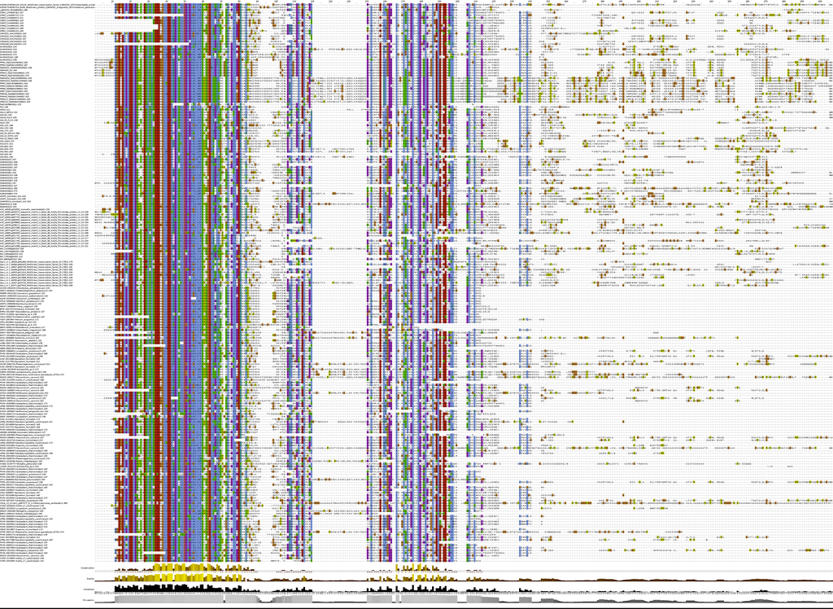

```bash
inseq=MIKC_orthogroup_selection-basal-v4_guide-v4
ls data/alignments_trimmed/"$inseq"_aligned*fasta
```

```
(phylogenetics) data/alignments_trimmed/MIKC_orthogroup_selection-basal-v4_guide-v4_aligned-mafft-einsi_trim-gt1.fasta
data/alignments_trimmed/MIKC_orthogroup_selection-basal-v4_guide-v4_aligned-mafft-einsi_trim-gt1-seqrmmanual.fasta
(phylogenetics)
```

```bash
conda activate phylogenetics
```

```bash
a=data/alignments_trimmed/MIKC_orthogroup_selection-basal-v3_guide-v4_aligned-mafft-einsi_trim-gt1-seqrmmanual.fasta

iqpendix='iqtree-b100'
#iqpendix='iqtree-MFP-bb2000-alrt2000'

echo "making a tree of file $a"
echo "The first lines of alignment $a look like this"
head $a

file_appendix=$(echo $a | cut -d '/' -f 3- | sed "s/$inseq\_//" | sed "s/.fasta//")
echo "Making a directory $file_appendix to store trees (name based on alignment filename)"

if   [ ! -d    analyses/"$inseq"_trees/"$file_appendix" ]
then mkdir -p  analyses/"$inseq"_trees/"$file_appendix"
fi

iqprefix=analyses/"$inseq"_trees/"$file_appendix"/"$inseq"_"$file_appendix"_"$iqpendix"
if   [ ! -f analyses/"$inseq"_trees/"$file_appendix"/"$inseq"_"$file_appendix"_iqtree-bb1000.tree ]
then nice iqtree -s $a \
                 -m 'MFP' \
                 -b 100 \
                 -nt AUTO \
                 -ntmax $(nproc)  \
                 -pre  "$iqprefix" \
                 2>   "$iqprefix".stderr \
                 >    "$iqprefix".stdout && cat "$iqprefix".log | mail -s IQtree_run laura &
fi
```

```
(phylogenetics) (phylogenetics) (phylogenetics) (phylogenetics) (phylogenetics) making a tree of file data/alignments_trimmed/MIKC_orthogroup_selection-basal-v3_guide-v4_aligned-mafft-einsi_trim-gt1-seqrmmanual.fasta
(phylogenetics) The first lines of alignment data/alignments_trimmed/MIKC_orthogroup_selection-basal-v3_guide-v4_aligned-mafft-einsi_trim-gt1-seqrmmanual.fasta look like this
(phylogenetics) >tr|Q5KU24|Q5KU24_COLSC_MADS-box_transcription_factor_CsMADS1_OS=Coleochaete_scutata_OX=3125_GN=csmads1_PE=2_SV=1
------MGRGKIEIRRIENATSRQVTFSKRRNGLLKKAYELSVLCDVDIAVIVFSPTGKL
FQYASS-SMKEILERYEQVPPEQKEK-----GSQRLDNM-DYLNREVAKLRNEVEHKYHE
ARQLEGEDLDRLGVYELEQLEQKLSNSMRRIRGRKDELMKAELEGLRKQVADMETASNYL
LQSIPGIRTMPSLGG-------------------------------NPA-----------
----------------------STSLQLGSDRLFGNRGSQAAAAAQQEWKN--ASSPTDW
KTEDSWPWVQPEWKNQ
>tr|Q5KTX4|Q5KTX4_9VIRI_MADS-box_protein_CpMADS1_(Fragment)_OS=Closterium_peracerosum-strigosum-littorale_complex_OX=34146_GN=CpMADS1_PE=2_SV=1
------MGRGKIEIRKIDNATTRQVTFSKRRNGLLKKAYELAVLCDVEIGVIIFSATGKL
FQYAST-NMDSIVERYRRLALRPPWQ-----QQNPPQSTPGQLQARTQQQRQQLSRLQAE
(phylogenetics) (phylogenetics) (phylogenetics) Making a directory MIKC_orthogroup_selection-basal-v3_guide-v4_aligned-mafft-einsi_trim-gt1-seqrmmanual to store trees (name based on alignment filename)
(phylogenetics) (phylogenetics) (phylogenetics) (phylogenetics) (phylogenetics) [1] 29848
(phylogenetics)
```

```bash
tail -n 30 $iqprefix.log
```

```
Iteration 330 / LogL: -56247.713 / Time: 0h:14m:12s (0h:3m:22s left)
Iteration 340 / LogL: -56247.197 / Time: 0h:14m:36s (0h:2m:55s left)
Iteration 350 / LogL: -56256.066 / Time: 0h:14m:59s (0h:2m:29s left)
Estimate model parameters (epsilon = 0.100)
BETTER TREE FOUND at iteration 357: -56230.385
Iteration 360 / LogL: -56271.003 / Time: 0h:15m:22s (0h:4m:9s left)
Iteration 370 / LogL: -56259.969 / Time: 0h:15m:48s (0h:3m:43s left)
Iteration 380 / LogL: -56234.284 / Time: 0h:16m:11s (0h:3m:17s left)
Iteration 390 / LogL: -56258.935 / Time: 0h:16m:35s (0h:2m:51s left)
Iteration 400 / LogL: -56286.262 / Time: 0h:16m:59s (0h:2m:25s left)
Iteration 410 / LogL: -56244.922 / Time: 0h:17m:23s (0h:1m:59s left)
Estimate model parameters (epsilon = 0.100)
BETTER TREE FOUND at iteration 419: -56229.714
Iteration 420 / LogL: -56247.481 / Time: 0h:17m:48s (0h:4m:12s left)
Iteration 430 / LogL: -56252.439 / Time: 0h:18m:13s (0h:3m:46s left)
Estimate model parameters (epsilon = 0.100)
BETTER TREE FOUND at iteration 433: -56229.677
Iteration 440 / LogL: -56237.865 / Time: 0h:18m:36s (0h:3m:56s left)
Iteration 450 / LogL: -56240.653 / Time: 0h:19m:0s (0h:3m:30s left)
Iteration 460 / LogL: -56238.996 / Time: 0h:19m:24s (0h:3m:5s left)
Iteration 470 / LogL: -56243.470 / Time: 0h:19m:47s (0h:2m:39s left)
Iteration 480 / LogL: -56251.452 / Time: 0h:20m:12s (0h:2m:14s left)
Iteration 490 / LogL: -56237.825 / Time: 0h:20m:36s (0h:1m:48s left)
Iteration 500 / LogL: -56231.620 / Time: 0h:21m:1s (0h:1m:23s left)
Estimate model parameters (epsilon = 0.100)
BETTER TREE FOUND at iteration 503: -56229.043
Iteration 510 / LogL: -56294.685 / Time: 0h:21m:25s (0h:3m:54s left)
Iteration 520 / LogL: -56249.993 / Time: 0h:21m:48s (0h:3m:29s left)
Iteration 530 / LogL: -56248.364 / Time: 0h:22m:12s (0h:3m:3s left)
Iteration 540 / LogL: -56231.326 / Time: 0h:22m:37s (0h:2m:38s left)
(phylogenetics)
```

```bash
grep 'START BOOTSTRAP'  $iqprefix.log -c
grep 'START BOOTSTRAP'  $iqprefix.log
```

```
51
(phylogenetics) ===> START BOOTSTRAP REPLICATE NUMBER 1
===> START BOOTSTRAP REPLICATE NUMBER 2
===> START BOOTSTRAP REPLICATE NUMBER 3
===> START BOOTSTRAP REPLICATE NUMBER 4
===> START BOOTSTRAP REPLICATE NUMBER 5
===> START BOOTSTRAP REPLICATE NUMBER 6
===> START BOOTSTRAP REPLICATE NUMBER 7
===> START BOOTSTRAP REPLICATE NUMBER 8
===> START BOOTSTRAP REPLICATE NUMBER 9
===> START BOOTSTRAP REPLICATE NUMBER 10
===> START BOOTSTRAP REPLICATE NUMBER 11
===> START BOOTSTRAP REPLICATE NUMBER 12
===> START BOOTSTRAP REPLICATE NUMBER 13
===> START BOOTSTRAP REPLICATE NUMBER 14
===> START BOOTSTRAP REPLICATE NUMBER 15
===> START BOOTSTRAP REPLICATE NUMBER 16
===> START BOOTSTRAP REPLICATE NUMBER 17
===> START BOOTSTRAP REPLICATE NUMBER 18
===> START BOOTSTRAP REPLICATE NUMBER 19
===> START BOOTSTRAP REPLICATE NUMBER 20
===> START BOOTSTRAP REPLICATE NUMBER 21
===> START BOOTSTRAP REPLICATE NUMBER 22
===> START BOOTSTRAP REPLICATE NUMBER 23
===> START BOOTSTRAP REPLICATE NUMBER 24
===> START BOOTSTRAP REPLICATE NUMBER 25
===> START BOOTSTRAP REPLICATE NUMBER 26
===> START BOOTSTRAP REPLICATE NUMBER 27
===> START BOOTSTRAP REPLICATE NUMBER 28
===> START BOOTSTRAP REPLICATE NUMBER 29
===> START BOOTSTRAP REPLICATE NUMBER 30
===> START BOOTSTRAP REPLICATE NUMBER 31
===> START BOOTSTRAP REPLICATE NUMBER 32
===> START BOOTSTRAP REPLICATE NUMBER 33
===> START BOOTSTRAP REPLICATE NUMBER 34
===> START BOOTSTRAP REPLICATE NUMBER 35
===> START BOOTSTRAP REPLICATE NUMBER 36
===> START BOOTSTRAP REPLICATE NUMBER 37
===> START BOOTSTRAP REPLICATE NUMBER 38
===> START BOOTSTRAP REPLICATE NUMBER 39
===> START BOOTSTRAP REPLICATE NUMBER 40
===> START BOOTSTRAP REPLICATE NUMBER 41
===> START BOOTSTRAP REPLICATE NUMBER 42
===> START BOOTSTRAP REPLICATE NUMBER 43
===> START BOOTSTRAP REPLICATE NUMBER 44
===> START BOOTSTRAP REPLICATE NUMBER 45
===> START BOOTSTRAP REPLICATE NUMBER 46
===> START BOOTSTRAP REPLICATE NUMBER 47
===> START BOOTSTRAP REPLICATE NUMBER 48
===> START BOOTSTRAP REPLICATE NUMBER 49
===> START BOOTSTRAP REPLICATE NUMBER 50
===> START BOOTSTRAP REPLICATE NUMBER 51
(phylogenetics)
```

```bash
grep 'Total wall-clock time used:'  $iqprefix.log -c
grep 'Total wall-clock time used:'  $iqprefix.log #| cut -d ':' -f 2 | cut -d ' ' -f 2
```

```
50
(phylogenetics) Total wall-clock time used: 1824.522 sec (0h:30m:24s)
Total wall-clock time used: 744.728 sec (0h:12m:24s)
Total wall-clock time used: 1873.262 sec (0h:31m:13s)
Total wall-clock time used: 799.357 sec (0h:13m:19s)
Total wall-clock time used: 863.983 sec (0h:14m:23s)
Total wall-clock time used: 1640.990 sec (0h:27m:20s)
Total wall-clock time used: 1036.143 sec (0h:17m:16s)
Total wall-clock time used: 1143.690 sec (0h:19m:3s)
Total wall-clock time used: 733.901 sec (0h:12m:13s)
Total wall-clock time used: 2150.139 sec (0h:35m:50s)
Total wall-clock time used: 1708.405 sec (0h:28m:28s)
Total wall-clock time used: 1322.112 sec (0h:22m:2s)
Total wall-clock time used: 726.797 sec (0h:12m:6s)
Total wall-clock time used: 1921.855 sec (0h:32m:1s)
Total wall-clock time used: 947.483 sec (0h:15m:47s)
Total wall-clock time used: 2331.695 sec (0h:38m:51s)
Total wall-clock time used: 762.739 sec (0h:12m:42s)
Total wall-clock time used: 1776.778 sec (0h:29m:36s)
Total wall-clock time used: 1141.909 sec (0h:19m:1s)
Total wall-clock time used: 741.096 sec (0h:12m:21s)
Total wall-clock time used: 1256.013 sec (0h:20m:56s)
Total wall-clock time used: 1866.554 sec (0h:31m:6s)
Total wall-clock time used: 2594.450 sec (0h:43m:14s)
Total wall-clock time used: 822.935 sec (0h:13m:42s)
Total wall-clock time used: 1404.341 sec (0h:23m:24s)
Total wall-clock time used: 1642.215 sec (0h:27m:22s)
Total wall-clock time used: 732.447 sec (0h:12m:12s)
Total wall-clock time used: 1367.766 sec (0h:22m:47s)
Total wall-clock time used: 825.107 sec (0h:13m:45s)
Total wall-clock time used: 2687.206 sec (0h:44m:47s)
Total wall-clock time used: 1234.591 sec (0h:20m:34s)
Total wall-clock time used: 810.708 sec (0h:13m:30s)
Total wall-clock time used: 1642.881 sec (0h:27m:22s)
Total wall-clock time used: 740.861 sec (0h:12m:20s)
Total wall-clock time used: 876.490 sec (0h:14m:36s)
Total wall-clock time used: 1109.132 sec (0h:18m:29s)
Total wall-clock time used: 871.016 sec (0h:14m:31s)
Total wall-clock time used: 1058.863 sec (0h:17m:38s)
Total wall-clock time used: 1252.126 sec (0h:20m:52s)
Total wall-clock time used: 1582.865 sec (0h:26m:22s)
Total wall-clock time used: 1190.265 sec (0h:19m:50s)
Total wall-clock time used: 1552.429 sec (0h:25m:52s)
Total wall-clock time used: 1102.675 sec (0h:18m:22s)
Total wall-clock time used: 1100.478 sec (0h:18m:20s)
Total wall-clock time used: 1706.617 sec (0h:28m:26s)
Total wall-clock time used: 1039.499 sec (0h:17m:19s)
Total wall-clock time used: 705.384 sec (0h:11m:45s)
Total wall-clock time used: 1230.874 sec (0h:20m:30s)
Total wall-clock time used: 1665.013 sec (0h:27m:45s)
Total wall-clock time used: 1978.078 sec (0h:32m:58s)
(phylogenetics)
```

Now let's try something completely different:

```bash
inseq=MIKC_orthogroup_selection-basal-v4_guide-v4
ls data/alignments_trimmed/"$inseq"_aligned*fasta
```

```
data/alignments_trimmed/MIKC_orthogroup_selection-basal-v4_guide-v4_aligned-mafft-einsi_trim-gt1.fasta
data/alignments_trimmed/MIKC_orthogroup_selection-basal-v4_guide-v4_aligned-mafft-einsi_trim-gt1-seqrmmanual2.fasta
data/alignments_trimmed/MIKC_orthogroup_selection-basal-v4_guide-v4_aligned-mafft-einsi_trim-gt1-seqrmmanual.fasta
```

```bash
conda activate phylogenetics
```

```
(phylogenetics)
```

```bash
a=data/alignments_trimmed/MIKC_orthogroup_selection-basal-v4_guide-v4_aligned-mafft-einsi_trim-gt1-seqrmmanual2.fasta

#iqpendix='iqtree-b100'
iqpendix='iqtree-MFP-bb2000-alrt2000'

echo "making a tree of file $a"
echo "The first lines of alignment $a look like this"
head $a

file_appendix=$(echo $a | cut -d '/' -f 3- | sed "s/$inseq\_//" | sed "s/.fasta//")
echo "Making a directory $file_appendix to store trees (name based on alignment filename)"

if   [ ! -d    analyses/"$inseq"_trees/"$file_appendix" ]
then mkdir -p  analyses/"$inseq"_trees/"$file_appendix"
fi

iqprefix=analyses/"$inseq"_trees/"$file_appendix"/"$inseq"_"$file_appendix"_"$iqpendix"
if   [ ! -f analyses/"$inseq"_trees/"$file_appendix"/"$inseq"_"$file_appendix"_iqtree-bb1000.tree ]
then nice iqtree -s $a \
                 -m 'MFP' \
                 -bb 2000 -alrt 2000 \
                 -nt AUTO \
                 -ntmax $(nproc)  \
                 -pre  "$iqprefix" \
                 2>   "$iqprefix".stderr \
                 >    "$iqprefix".stdout && cat "$iqprefix".log | mail -s IQtree_run laura &
fi
```

```
(phylogenetics) (phylogenetics) (phylogenetics) (phylogenetics) (phylogenetics) making a tree of file data/alignments_trimmed/MIKC_orthogroup_selection-basal-v4_guide-v4_aligned-mafft-einsi_trim-gt1-seqrmmanual2.fasta
(phylogenetics) The first lines of alignment data/alignments_trimmed/MIKC_orthogroup_selection-basal-v4_guide-v4_aligned-mafft-einsi_trim-gt1-seqrmmanual2.fasta look like this
(phylogenetics) >tr|Q5KU24|Q5KU24_COLSC_MADS-box_transcription_factor_CsMADS1_OS=Coleochaete_scutata_OX=3125_GN=csmads1_PE=2_SV=1/1-170
MGRGKIEIRRIENATSRQVTFSKRRNGLLKKAYELSVLCDVDIAVIVFSPTGKLFQYASSSMKEILERYEQV
PPEQKEQRLDNMDYLNREVAKLRNEVEHKYHEARQLEGEDLDRLGVYELEQLEQKLSNSMRRIRGRKDELMK
AELEGLRKQVADMETALVALLQSIPG
>tr|Q5KTX4|Q5KTX4_9VIRI_MADS-box_protein_CpMADS1_(Fragment)_OS=Closterium_peracerosum-strigosum-littorale_complex_OX=34146_GN=CpMADS1_PE=2_SV=1/1-159
MGRGKIEIRKIDNATTRQVTFSKRRNGLLKKAYELAVLCDVEIGVIIFSATGKLFQYASTNMDSIVERYRRL
ALETQSRTQEDTK-KAAEPQPLDLELSRLQAEQRALVAESFEGLGLEEMRQLEKQLEASLSRLRERKEELFN
RTISELKSR---LEGRSKA-------
>cgMADS1_BAD88436/1-162
MGRAKIEIKRIDNATSRQVTFSKRRNGLLKKAYELSVLCDADIAVIMFSPTGKLFEYANSSMKEILDRYHSC
(phylogenetics) (phylogenetics) (phylogenetics) Making a directory aligned-mafft-einsi_trim-gt1-seqrmmanual2 to store trees (name based on alignment filename)
(phylogenetics) (phylogenetics) (phylogenetics) (phylogenetics) (phylogenetics) [1] 47386
(phylogenetics)
```

```bash
tail -n 30 $iqprefix.log
```

```
 208  PIVW-2007999-Ceratopteris_thalictroides_1-166                                                                                                           2.35%    passed      6.39%
 209  NRWZ-2014421-Metzgeria_crassipilis_1-169                                                                                                                0.59%    passed     77.73%
 210  PIVW-2001493-Ceratopteris_thalictroides_1-152                                                                                                          10.59%    passed     64.49%
 211  RDOO-2015055-Racomitrium_varium_1-164                                                                                                                   3.53%    passed     82.03%
 212  CVEG-2123825-Azolla_cf._caroliniana_1-147                                                                                                              13.53%    passed     89.04%
 213  CVEG-2010487-Azolla_cf._caroliniana_1-147                                                                                                              13.53%    passed     97.33%
****  TOTAL                                                                                                                                                   7.03%  4 sequences failed composition chi2 test (p-value<5%; df=19)
NOTE: CMADS3_AAC24319_1-164 is identical to CRM1_CAA69276_1-164 but kept for subsequent analysis
NOTE: PIVW-2001493-Ceratopteris_thalictroides_1-152 is identical to PIVW-2001489-Ceratopteris_thalictroides_1-152 but kept for subsequent analysis
NOTE: ZFRE-2001131-Phaeoceros_carolinianus-sporophyte_1575_1-170 is identical to ZFRE-2001130-Phaeoceros_carolinianus-sporophyte_1575_1-170 but kept for subsequent analysis
NOTE: RDOO-2005175-Racomitrium_varium_1-164 is identical to RDOO-2005177-Racomitrium_varium_1-164 but kept for subsequent analysis
NOTE: RDOO-2000122-Racomitrium_varium_1-169 is identical to RDOO-2000123-Racomitrium_varium_1-169 but kept for subsequent analysis
NOTE: RDOO-2000811-Racomitrium_varium_1-149 is identical to RDOO-2000812-Racomitrium_varium_1-149 but kept for subsequent analysis
NOTE: PIVW-2004035-Ceratopteris_thalictroides_1-168 is identical to PIVW-2004036-Ceratopteris_thalictroides_1-168 but kept for subsequent analysis
NOTE: UPMJ-2005049-Pseudolycopodiella_caroliniana_1-170 is identical to UPMJ-2005050-Pseudolycopodiella_caroliniana_1-170 but kept for subsequent analysis
NOTE: ENQF-2004631-Lycopodium_annotinum_1-139 is identical to ENQF-2004632-Lycopodium_annotinum_1-139 but kept for subsequent analysis
NOTE: PIVW-2007999-Ceratopteris_thalictroides_1-166 is identical to PIVW-2008000-Ceratopteris_thalictroides_1-166 but kept for subsequent analysis
NOTE: PIVW-2003992-Ceratopteris_thalictroides_1-168 is identical to PIVW-2003993-Ceratopteris_thalictroides_1-168 but kept for subsequent analysis
NOTE: PIVW-2009414-Ceratopteris_thalictroides_1-149 is identical to PIVW-2009413-Ceratopteris_thalictroides_1-149 but kept for subsequent analysis


Create initial parsimony tree by phylogenetic likelihood library (PLL)... 0.081 seconds
NOTE: ModelFinder requires 64 MB RAM!
ModelFinder will test 462 protein models (sample size: 170) ...
 No. Model         -LnL         df  AIC          AICc         BIC
Measuring multi-threading efficiency up to 4 CPU cores
Increase to 10 rounds for branch lengths
21 trees examined
Threads: 1 / Time: 4.179 sec / Speedup: 1.000 / Efficiency: 100% / LogL: -62641
Threads: 2 / Time: 2.901 sec / Speedup: 1.440 / Efficiency: 72% / LogL: -62641
(phylogenetics)
```

```bash
cat "$iqprefix".stderr
```

[output not shown]